# **The Evolution of Height in the NBA**

**Collaborators: Brian Diarra, Obinna Anako, Tyler Krauth, Jesuseyi Oyeyemi**

[figure not shown]

## **Introduction**

The [National Basketball Association (NBA)](https://www.nba.com/) is a men's professional basketball league in North America. It was founded in 1946, and since then has become one of the most popular sports leagues in the world. With millions of fans and followers, the NBA has produced some of the most iconic players in the history of the game. From the likes of Wilt Chamberlain to Shaquille O'Neal to LeBron James, the NBA has seen some of the greatest players of all time. One of the factors that have changed throughout the years in the NBA is the height of the players. In this tutorial, we will explore the evolution of height in the NBA, and how it has impacted the game.

**Motivation**

The main purpose of this project is to guide you through the entire pipeline of data science, focusing on the evolution of height in the NBA. Over the years, the game of basketball has evolved in many ways, with one notable aspect being the changing role of height in the sport. Looking at the past several decades, the average height of players in the National Basketball Association (NBA) has steadily increased. In the early days of the league, players were typically around 6 feet tall, but by the 1980s and 1990s, the average height had risen to around 6'7". In recent years, the trend has continued, with the average height of NBA players now hovering around 6'8". This increase in height can be attributed to a number of factors, including changes in training and nutrition, advancements in medical technology, and the increasing popularity of basketball around the world, which has led to a larger pool of tall and talented players. However, taller players, usually power forwards and centers, have gone from being primarily tough rebounders and shot blockers to exhibiting skills like shooting and playmaking, which were originally viewed as point guard and shooting guard specific skills, as seen in the rise of players like Victor Wembanyama. As height continues to play a significant role in the game, it's essential to understand its impact on the NBA landscape.

Why is this important? Analyzing the evolution of height in the NBA provides valuable insights into the changing dynamics of the sport. By understanding these changes, coaches, teams, and analysts can better adapt their strategies and develop more effective game plans. Moreover, such an analysis can also shed light on how the game has evolved in terms of athleticism and skill, ultimately enhancing the viewer experience for fans.

Throughout this tutorial, we will be going through the Data Science Lifecycle as follows:

1. Data Collection
2. Data Processing
3. Exploratory Analysis & Data Visualization
4. Model: Analysis, Hypothesis Testing, & ML
5. Interpretation: Insight & Policy Decision

## **Data Collection**

Our first step in the data science life cycle is to search for a dataset that fits our topic. We need information on NBA players' heights, the years they played, and additional data that might be relevant, such as their positions and statistics.

The Kaggle platform, known for hosting a wide variety of datasets, provides us with an ideal source. We found a dataset named "NBA Players stats since 1950" at https://www.kaggle.com/drgilermo/nba-players-stats. This dataset is rich in detail and spans a good period, giving us enough data points to analyze the evolution of height in NBA players.

**To download the dataset:**

Visit the above link. Click on the “Download” button. Unzip the downloaded file and you will find three CSV files: **player_data.csv**, **players.csv**, and **seasons_stats.csv**. In this tutorial, we will be interested in all 3 files. Make sure to store the files file in your project directory.

During this project, we will be using the Python language, and we use tools such as IPython and Jupyter Notebook to develop this project. If you haven't heard about Jupyter notebooks before, make sure to learn more about them [here.](https://jupyter.org/)

To start any Python project, we need to import some libraries. Here are some of the libraries we will be using throughout this tutorial:

```python
import numpy as np
import pandas as pd
import os
import datetime
import seaborn as sns
import matplotlib.pyplot as plt
from sklearn.linear_model import LinearRegression
```

```python
players = pd.read_csv("Players.csv")
seasons_stats = pd.read_csv("Seasons_Stats.csv")
player_data = pd.read_csv("player_data.csv")
```

```python
players.head()
```

|  | Unnamed: 0 | Player | height | weight | collage | born | birth_city | birth_state |
| --- | --- | --- | --- | --- | --- | --- | --- | --- |
| 0 | 0 | Curly Armstrong | 180.0 | 77.0 | Indiana University | 1918.0 | NaN | NaN |
| 1 | 1 | Cliff Barker | 188.0 | 83.0 | University of Kentucky | 1921.0 | Yorktown | Indiana |
| 2 | 2 | Leo Barnhorst | 193.0 | 86.0 | University of Notre Dame | 1924.0 | NaN | NaN |
| 3 | 3 | Ed Bartels | 196.0 | 88.0 | North Carolina State University | 1925.0 | NaN | NaN |
| 4 | 4 | Ralph Beard | 178.0 | 79.0 | University of Kentucky | 1927.0 | Hardinsburg | Kentucky |

```python
seasons_stats.head()
```

|  | Unnamed: 0 | Year | Player | Pos | Age | Tm | G | GS | MP | PER | ... | FT% | ORB | DRB | TRB | AST | STL | BLK | TOV | PF | PTS |
| --- | --- | --- | --- | --- | --- | --- | --- | --- | --- | --- | --- | --- | --- | --- | --- | --- | --- | --- | --- | --- | --- |
| 0 | 0 | 1950.0 | Curly Armstrong | G-F | 31.0 | FTW | 63.0 | NaN | NaN | NaN | ... | 0.705 | NaN | NaN | NaN | 176.0 | NaN | NaN | NaN | 217.0 | 458.0 |
| 1 | 1 | 1950.0 | Cliff Barker | SG | 29.0 | INO | 49.0 | NaN | NaN | NaN | ... | 0.708 | NaN | NaN | NaN | 109.0 | NaN | NaN | NaN | 99.0 | 279.0 |
| 2 | 2 | 1950.0 | Leo Barnhorst | SF | 25.0 | CHS | 67.0 | NaN | NaN | NaN | ... | 0.698 | NaN | NaN | NaN | 140.0 | NaN | NaN | NaN | 192.0 | 438.0 |
| 3 | 3 | 1950.0 | Ed Bartels | F | 24.0 | TOT | 15.0 | NaN | NaN | NaN | ... | 0.559 | NaN | NaN | NaN | 20.0 | NaN | NaN | NaN | 29.0 | 63.0 |
| 4 | 4 | 1950.0 | Ed Bartels | F | 24.0 | DNN | 13.0 | NaN | NaN | NaN | ... | 0.548 | NaN | NaN | NaN | 20.0 | NaN | NaN | NaN | 27.0 | 59.0 |

5 rows × 53 columns

```python
player_data.head()
```

|  | name | year_start | year_end | position | height | weight | birth_date | college |
| --- | --- | --- | --- | --- | --- | --- | --- | --- |
| 0 | Alaa Abdelnaby | 1991 | 1995 | F-C | 6-10 | 240.0 | June 24, 1968 | Duke University |
| 1 | Zaid Abdul-Aziz | 1969 | 1978 | C-F | 6-9 | 235.0 | April 7, 1946 | Iowa State University |
| 2 | Kareem Abdul-Jabbar | 1970 | 1989 | C | 7-2 | 225.0 | April 16, 1947 | University of California, Los Angeles |
| 3 | Mahmoud Abdul-Rauf | 1991 | 2001 | G | 6-1 | 162.0 | March 9, 1969 | Louisiana State University |
| 4 | Tariq Abdul-Wahad | 1998 | 2003 | F | 6-6 | 223.0 | November 3, 1974 | San Jose State University |

```python
players= players.rename(columns={"Player": "name"})
seasons_stats = seasons_stats.rename(columns={"Player": "name"})
```

We then separate the data into decades so we can analyze how each decade changed.

```python
season1980s =seasons_stats[(seasons_stats.Year >= 1980) & (seasons_stats.Year < 1990)]
season1980s = season1980s.groupby(['Year', 'name']).sum().reset_index()
season1980s = season1980s.drop('Unnamed: 0', axis =1)
season1980s.head()
```

|  | Year | name | Age | G | GS | MP | PER | TS% | 3PAr | FTr | ... | FT% | ORB | DRB | TRB | AST | STL | BLK | TOV | PF | PTS |
| --- | --- | --- | --- | --- | --- | --- | --- | --- | --- | --- | --- | --- | --- | --- | --- | --- | --- | --- | --- | --- | --- |
| 0 | 1980.0 | Abdul Jeelani | 25.0 | 77.0 | 0.0 | 1286.0 | 18.7 | 0.563 | 0.011 | 0.361 | ... | 0.789 | 114.0 | 156.0 | 270.0 | 95.0 | 40.0 | 40.0 | 117.0 | 155.0 | 737.0 |
| 1 | 1980.0 | Adrian Dantley* | 23.0 | 68.0 | 0.0 | 2674.0 | 24.3 | 0.635 | 0.002 | 0.415 | ... | 0.842 | 183.0 | 333.0 | 516.0 | 191.0 | 96.0 | 14.0 | 233.0 | 211.0 | 1903.0 |
| 2 | 1980.0 | Al Skinner | 27.0 | 2.0 | 0.0 | 10.0 | -0.6 | 0.500 | 0.000 | 0.000 | ... | 0.000 | 0.0 | 0.0 | 0.0 | 2.0 | 0.0 | 0.0 | 2.0 | 1.0 | 2.0 |
| 3 | 1980.0 | Alex English* | 78.0 | 156.0 | 0.0 | 4802.0 | 54.2 | 1.606 | 0.016 | 0.738 | ... | 2.365 | 538.0 | 672.0 | 1210.0 | 448.0 | 146.0 | 124.0 | 428.0 | 412.0 | 2636.0 |
| 4 | 1980.0 | Allan Bristow | 28.0 | 82.0 | 0.0 | 2304.0 | 16.6 | 0.534 | 0.009 | 0.310 | ... | 0.811 | 170.0 | 342.0 | 512.0 | 341.0 | 88.0 | 6.0 | 179.0 | 211.0 | 953.0 |

5 rows × 50 columns

```python
season1990s =seasons_stats[(seasons_stats.Year >= 1990) & (seasons_stats.Year < 2000)]
season1990s = season1990s.groupby(['Year', 'name']).sum().reset_index()
season1990s = season1990s.drop('Unnamed: 0', axis =1)
season1990s.head()
```

|  | Year | name | Age | G | GS | MP | PER | TS% | 3PAr | FTr | ... | FT% | ORB | DRB | TRB | AST | STL | BLK | TOV | PF | PTS |
| --- | --- | --- | --- | --- | --- | --- | --- | --- | --- | --- | --- | --- | --- | --- | --- | --- | --- | --- | --- | --- | --- |
| 0 | 1990.0 | A.C. Green | 26.0 | 82.0 | 82.0 | 2709.0 | 14.7 | 0.548 | 0.057 | 0.459 | ... | 0.751 | 262.0 | 450.0 | 712.0 | 90.0 | 66.0 | 50.0 | 116.0 | 207.0 | 1061.0 |
| 1 | 1990.0 | Adrian Branch | 26.0 | 11.0 | 0.0 | 91.0 | 16.9 | 0.460 | 0.016 | 0.361 | ... | 0.636 | 8.0 | 12.0 | 20.0 | 4.0 | 6.0 | 0.0 | 8.0 | 14.0 | 65.0 |
| 2 | 1990.0 | Adrian Caldwell | 23.0 | 51.0 | 0.0 | 331.0 | 9.5 | 0.549 | 0.000 | 0.368 | ... | 0.464 | 36.0 | 73.0 | 109.0 | 7.0 | 11.0 | 18.0 | 32.0 | 69.0 | 97.0 |
| 3 | 1990.0 | Adrian Dantley* | 33.0 | 45.0 | 45.0 | 1300.0 | 15.4 | 0.556 | 0.004 | 0.525 | ... | 0.787 | 78.0 | 94.0 | 172.0 | 80.0 | 20.0 | 7.0 | 75.0 | 99.0 | 662.0 |
| 4 | 1990.0 | Alex English* | 36.0 | 80.0 | 80.0 | 2211.0 | 17.9 | 0.522 | 0.004 | 0.142 | ... | 0.880 | 119.0 | 167.0 | 286.0 | 225.0 | 51.0 | 23.0 | 93.0 | 130.0 | 1433.0 |

5 rows × 50 columns

```python
season2000s =seasons_stats[(seasons_stats.Year >= 2000) & (seasons_stats.Year < 2010)]
season2000s = season2000s.groupby(['Year', 'name']).sum().reset_index()
season2000s = season2000s.drop('Unnamed: 0', axis =1)
season2000s.head()
```

|  | Year | name | Age | G | GS | MP | PER | TS% | 3PAr | FTr | ... | FT% | ORB | DRB | TRB | AST | STL | BLK | TOV | PF | PTS |
| --- | --- | --- | --- | --- | --- | --- | --- | --- | --- | --- | --- | --- | --- | --- | --- | --- | --- | --- | --- | --- | --- |
| 0 | 2000.0 | A.C. Green | 36.0 | 82.0 | 82.0 | 1929.0 | 11.2 | 0.482 | 0.010 | 0.245 | ... | 0.695 | 160.0 | 326.0 | 486.0 | 80.0 | 53.0 | 18.0 | 53.0 | 127.0 | 413.0 |
| 1 | 2000.0 | A.J. Bramlett | 23.0 | 8.0 | 0.0 | 61.0 | -0.4 | 0.190 | 0.000 | 0.000 | ... | 0.000 | 12.0 | 10.0 | 22.0 | 0.0 | 1.0 | 0.0 | 3.0 | 13.0 | 8.0 |
| 2 | 2000.0 | Aaron McKie | 27.0 | 82.0 | 14.0 | 1952.0 | 13.2 | 0.497 | 0.204 | 0.246 | ... | 0.829 | 47.0 | 199.0 | 246.0 | 240.0 | 108.0 | 18.0 | 113.0 | 194.0 | 653.0 |
| 3 | 2000.0 | Aaron Williams | 28.0 | 81.0 | 0.0 | 1545.0 | 17.7 | 0.572 | 0.007 | 0.447 | ... | 0.726 | 159.0 | 250.0 | 409.0 | 58.0 | 41.0 | 92.0 | 80.0 | 234.0 | 616.0 |
| 4 | 2000.0 | Adam Keefe | 29.0 | 62.0 | 3.0 | 604.0 | 7.6 | 0.463 | 0.008 | 0.277 | ... | 0.806 | 45.0 | 91.0 | 136.0 | 34.0 | 17.0 | 13.0 | 46.0 | 90.0 | 135.0 |

5 rows × 50 columns

```python
season2010s =seasons_stats[(seasons_stats.Year >= 2010) & (seasons_stats.Year < 2017)]
season2010s = season2010s.groupby(['Year', 'name']).sum().reset_index()
season2010s = season2010s.drop('Unnamed: 0', axis =1)
season2010s.head()
```

|  | Year | name | Age | G | GS | MP | PER | TS% | 3PAr | FTr | ... | FT% | ORB | DRB | TRB | AST | STL | BLK | TOV | PF | PTS |
| --- | --- | --- | --- | --- | --- | --- | --- | --- | --- | --- | --- | --- | --- | --- | --- | --- | --- | --- | --- | --- | --- |
| 0 | 2010.0 | A.J. Price | 23.0 | 56.0 | 2.0 | 865.0 | 14.0 | 0.530 | 0.492 | 0.212 | ... | 0.800 | 12.0 | 76.0 | 88.0 | 106.0 | 35.0 | 3.0 | 59.0 | 53.0 | 410.0 |
| 1 | 2010.0 | Aaron Brooks | 25.0 | 82.0 | 82.0 | 2919.0 | 16.0 | 0.549 | 0.394 | 0.224 | ... | 0.822 | 54.0 | 161.0 | 215.0 | 434.0 | 69.0 | 14.0 | 232.0 | 199.0 | 1604.0 |
| 2 | 2010.0 | Aaron Gray | 75.0 | 64.0 | 0.0 | 622.0 | 42.0 | 1.537 | 0.000 | 1.018 | ... | 1.857 | 90.0 | 122.0 | 212.0 | 44.0 | 18.0 | 22.0 | 36.0 | 108.0 | 208.0 |
| 3 | 2010.0 | Acie Law | 100.0 | 52.0 | 2.0 | 468.0 | 60.2 | 2.336 | 0.757 | 2.762 | ... | 3.174 | 6.0 | 28.0 | 34.0 | 52.0 | 22.0 | 2.0 | 34.0 | 32.0 | 226.0 |
| 4 | 2010.0 | Adam Morrison | 25.0 | 31.0 | 0.0 | 241.0 | 7.4 | 0.418 | 0.247 | 0.094 | ... | 0.625 | 10.0 | 22.0 | 32.0 | 18.0 | 3.0 | 2.0 | 10.0 | 17.0 | 74.0 |

5 rows × 50 columns

**Data Transformation**

In the code above, "player" is the existing column name and "name" is the new column name. After running this code, the column originally named "player" in the players DataFrame will be renamed to "name".

This was done to allow merge Merging datasets allows us to combine relevant data from different sources into a single dataframe that we can analyze. We used an inner join to merge our datasets, which means that only the rows with matching 'name' values in both dataframes are included in the output.

We also dropped certain columns from our dataset that were not relevant to our analysis. For instance,'height_y', 'weight_y', 'collage', 'ORB%', 'DRB%', and 'TS%' were dropped because they do not contribute to our analysis on player height:

We also kept the players' height as cm to make it more understandable:

```python
merged_data = pd.merge(players,player_data, on='name', how='inner')
merged_data = merged_data.drop('height_y', axis=1)
merged_data = merged_data.drop('weight_y', axis=1)
merged_data = merged_data.drop('birth_city', axis=1)
merged_data = merged_data.drop('birth_state', axis=1)
merged_data["height_x"] = merged_data["height_x"]
merged_data.head()
```

|  | Unnamed: 0 | name | height_x | weight_x | collage | born | year_start | year_end | position | birth_date | college |
| --- | --- | --- | --- | --- | --- | --- | --- | --- | --- | --- | --- |
| 0 | 0 | Curly Armstrong | 180.0 | 77.0 | Indiana University | 1918.0 | 1949 | 1951 | G-F | November 1, 1918 | Indiana University |
| 1 | 1 | Cliff Barker | 188.0 | 83.0 | University of Kentucky | 1921.0 | 1950 | 1952 | G | January 15, 1921 | University of Kentucky |
| 2 | 2 | Leo Barnhorst | 193.0 | 86.0 | University of Notre Dame | 1924.0 | 1950 | 1954 | F-G | May 11, 1924 | University of Notre Dame |
| 3 | 3 | Ed Bartels | 196.0 | 88.0 | North Carolina State University | 1925.0 | 1950 | 1951 | F | October 8, 1925 | North Carolina State University |
| 4 | 4 | Ralph Beard | 178.0 | 79.0 | University of Kentucky | 1927.0 | 1950 | 1951 | G | December 2, 1927 | University of Kentucky |

```python
merged1980s = pd.merge( season1980s, merged_data, on='name', how='inner')
merged1980s = merged1980s.drop('collage', axis=1)
merged1980s = merged1980s.drop('ORB%', axis=1)
merged1980s = merged1980s.drop('DRB%', axis=1)
merged1980s = merged1980s.drop('TS%', axis=1)
season1980s = merged1980s[merged1980s.position == 'C']
season1980s.head()
```

|  | Year | name | Age | G | GS | MP | PER | 3PAr | FTr | TRB% | ... | PTS | Unnamed: 0 | height_x | weight_x | born | year_start | year_end | position | birth_date | college |
| --- | --- | --- | --- | --- | --- | --- | --- | --- | --- | --- | --- | --- | --- | --- | --- | --- | --- | --- | --- | --- | --- |
| 42 | 1980.0 | Arvid Kramer | 23.0 | 8.0 | 0.0 | 45.0 | 6.6 | 0.000 | 0.091 | 13.9 | ... | 16.0 | 1373 | 206.0 | 99.0 | 1956.0 | 1980 | 1980 | C | October 2, 1956 | Augustana College (SD) |
| 54 | 1980.0 | Bill Cartwright | 22.0 | 82.0 | 0.0 | 3150.0 | 17.9 | 0.000 | 0.466 | 12.6 | ... | 1781.0 | 1344 | 216.0 | 111.0 | 1957.0 | 1980 | 1995 | C | July 30, 1957 | University of San Francisco |
| 55 | 1981.0 | Bill Cartwright | 23.0 | 82.0 | 0.0 | 2925.0 | 18.4 | 0.001 | 0.463 | 12.0 | ... | 1646.0 | 1344 | 216.0 | 111.0 | 1957.0 | 1980 | 1995 | C | July 30, 1957 | University of San Francisco |
| 56 | 1982.0 | Bill Cartwright | 24.0 | 72.0 | 50.0 | 2060.0 | 16.3 | 0.000 | 0.486 | 11.7 | ... | 1037.0 | 1344 | 216.0 | 111.0 | 1957.0 | 1980 | 1995 | C | July 30, 1957 | University of San Francisco |
| 57 | 1983.0 | Bill Cartwright | 25.0 | 82.0 | 82.0 | 2468.0 | 19.0 | 0.000 | 0.636 | 14.0 | ... | 1290.0 | 1344 | 216.0 | 111.0 | 1957.0 | 1980 | 1995 | C | July 30, 1957 | University of San Francisco |

5 rows × 56 columns

```python
avg_ast_1980s = season1980s['AST'].mean()
avg_stl_1980s = season1980s['STL'].mean()
avg_blk_1980s = season1980s['BLK'].mean()
avg_3PAr_1980s = season1980s['3PAr'].mean()
avg_Points_1980s = season1980s['PTS'].mean()
avg_Games_1980s = season1980s['G'].mean()
avg_Starts_1980s = season1980s['GS'].mean()
avg_TRB_1980s = season1980s['TRB'].mean()
avg_TOV_1980s = season1980s['TOV'].mean()
avg_height_x_1980s = season1980s['height_x'].mean()
data_1980s = {
    "Decade": ["1980s"],
    "AST": [avg_ast_1980s],
    "STL": [avg_stl_1980s],
    "BLK": [avg_blk_1980s],
    "3PAr": [avg_3PAr_1980s],
    "PTS": [avg_Points_1980s],
    "G": [avg_Games_1980s],
    "GS": [avg_Starts_1980s],
    "TRB": [avg_TRB_1980s],
    "TOV": [avg_TOV_1980s],
    "height_x": [avg_height_x_1980s]
}

df_1980s_averages= pd.DataFrame(data_1980s)

df_1980s_averages.head()
```

|  | Decade | AST | STL | BLK | 3PAr | PTS | G | GS | TRB | TOV | height_x |
| --- | --- | --- | --- | --- | --- | --- | --- | --- | --- | --- | --- |
| 0 | 1980s | 68.327206 | 27.242647 | 68.775735 | 0.00675 | 467.213235 | 59.694853 | 23.169118 | 336.194853 | 84.051471 | 213.033088 |

```python
merged1990s = pd.merge( season1990s, merged_data, on='name', how='inner')
merged1990s = merged1990s.drop('collage', axis=1)
merged1990s = merged1990s.drop('ORB%', axis=1)
merged1990s = merged1990s.drop('DRB%', axis=1)
merged1990s = merged1990s.drop('TS%', axis=1)
season1990s = merged1990s[merged1990s.position == 'C']
season1990s.head()
```

|  | Year | name | Age | G | GS | MP | PER | 3PAr | FTr | TRB% | ... | PTS | Unnamed: 0 | height_x | weight_x | born | year_start | year_end | position | birth_date | college |
| --- | --- | --- | --- | --- | --- | --- | --- | --- | --- | --- | --- | --- | --- | --- | --- | --- | --- | --- | --- | --- | --- |
| 17 | 1990.0 | Alexander Volkov | 25.0 | 72.0 | 4.0 | 937.0 | 11.9 | 0.120 | 0.423 | 7.3 | ... | 357.0 | 2042 | 208.0 | 98.0 | 1964.0 | 1990 | 1992 | C | March 28, 1964 | NaN |
| 18 | 1992.0 | Alexander Volkov | 27.0 | 77.0 | 27.0 | 1516.0 | 15.5 | 0.193 | 0.348 | 9.3 | ... | 662.0 | 2042 | 208.0 | 98.0 | 1964.0 | 1990 | 1992 | C | March 28, 1964 | NaN |
| 35 | 1990.0 | Andrew Lang | 23.0 | 74.0 | 0.0 | 1011.0 | 13.2 | 0.000 | 0.563 | 14.7 | ... | 258.0 | 1928 | 211.0 | 111.0 | 1966.0 | 1989 | 2000 | C | June 28, 1966 | University of Arkansas |
| 36 | 1991.0 | Andrew Lang | 24.0 | 63.0 | 18.0 | 1152.0 | 13.6 | 0.005 | 0.688 | 14.4 | ... | 311.0 | 1928 | 211.0 | 111.0 | 1966.0 | 1989 | 2000 | C | June 28, 1966 | University of Arkansas |
| 37 | 1992.0 | Andrew Lang | 25.0 | 81.0 | 71.0 | 1965.0 | 13.8 | 0.002 | 0.345 | 15.3 | ... | 622.0 | 1928 | 211.0 | 111.0 | 1966.0 | 1989 | 2000 | C | June 28, 1966 | University of Arkansas |

5 rows × 56 columns

```python
avg_ast_1990s = season1990s['AST'].mean()
avg_stl_1990s = season1990s['STL'].mean()
avg_blk_1990s = season1990s['BLK'].mean()
avg_3PAr_1990s = season1990s['3PAr'].mean()
avg_Points_1990s = season1990s['PTS'].mean()
avg_Games_1990s = season1990s['G'].mean()
avg_Starts_1990s = season1990s['GS'].mean()
avg_TRB_1990s = season1990s['TRB'].mean()
avg_TOV_1990s = season1990s['TOV'].mean()
avg_height_x_1990s = season1990s['height_x'].mean()

data_1990s = {
    "Decade": ["1990s"],
    "AST": [avg_ast_1990s],
    "STL": [avg_stl_1990s],
    "BLK": [avg_blk_1990s],
    "3PAr": [avg_3PAr_1990s],
    "PTS": [avg_Points_1990s],
    "G": [avg_Games_1990s],
    "GS": [avg_Starts_1990s],
    "TRB": [avg_TRB_1990s],
    "TOV": [avg_TOV_1990s],
    "height_x": [avg_height_x_1990s]
}

df_1990s_averages = pd.DataFrame(data_1990s)

df_1990s_averages.head()
```

|  | Decade | AST | STL | BLK | 3PAr | PTS | G | GS | TRB | TOV | height_x |
| --- | --- | --- | --- | --- | --- | --- | --- | --- | --- | --- | --- |
| 0 | 1990s | 45.774617 | 22.967177 | 52.982495 | 0.016451 | 365.354486 | 52.196937 | 26.343545 | 268.527352 | 62.564551 | 212.768053 |

```python
merged2000s = pd.merge( season2000s, merged_data, on='name', how='inner')
merged2000s = merged2000s.drop('collage', axis=1)
merged2000s = merged2000s.drop('ORB%', axis=1)
merged2000s = merged2000s.drop('DRB%', axis=1)
merged2000s = merged2000s.drop('TS%', axis=1)
season2000s = merged2000s[merged2000s.position == 'C']
season2000s.head()
```

|  | Year | name | Age | G | GS | MP | PER | 3PAr | FTr | TRB% | ... | PTS | Unnamed: 0 | height_x | weight_x | born | year_start | year_end | position | birth_date | college |
| --- | --- | --- | --- | --- | --- | --- | --- | --- | --- | --- | --- | --- | --- | --- | --- | --- | --- | --- | --- | --- | --- |
| 2 | 2000.0 | A.J. Bramlett | 23.0 | 8.0 | 0.0 | 61.0 | -0.4 | 0.000 | 0.000 | 20.1 | ... | 8.0 | 2657 | 196.0 | 88.0 | 1973.0 | 2000 | 2000 | C | January 10, 1977 | University of Arizona |
| 22 | 2000.0 | Adonal Foyle | 24.0 | 76.0 | 59.0 | 1654.0 | 12.3 | 0.000 | 0.237 | 13.5 | ... | 420.0 | 2538 | 208.0 | 113.0 | 1975.0 | 1998 | 2009 | C | March 9, 1975 | Colgate University |
| 23 | 2001.0 | Adonal Foyle | 25.0 | 58.0 | 37.0 | 1457.0 | 12.4 | 0.000 | 0.181 | 14.7 | ... | 342.0 | 2538 | 208.0 | 113.0 | 1975.0 | 1998 | 2009 | C | March 9, 1975 | Colgate University |
| 24 | 2002.0 | Adonal Foyle | 26.0 | 79.0 | 36.0 | 1485.0 | 12.5 | 0.000 | 0.242 | 13.9 | ... | 379.0 | 2538 | 208.0 | 113.0 | 1975.0 | 1998 | 2009 | C | March 9, 1975 | Colgate University |
| 25 | 2003.0 | Adonal Foyle | 27.0 | 82.0 | 0.0 | 1787.0 | 15.3 | 0.003 | 0.301 | 14.6 | ... | 440.0 | 2538 | 208.0 | 113.0 | 1975.0 | 1998 | 2009 | C | March 9, 1975 | Colgate University |

5 rows × 56 columns

```python
avg_ast_2000s = season2000s['AST'].mean()
avg_stl_2000s = season2000s['STL'].mean()
avg_blk_2000s = season2000s['BLK'].mean()
avg_3PAr_2000s = season2000s['3PAr'].mean()
avg_Points_2000s = season2000s['PTS'].mean()
avg_Games_2000s = season2000s['G'].mean()
avg_Starts_2000s = season2000s['GS'].mean()
avg_TRB_2000s = season2000s['TRB'].mean()
avg_TOV_2000s = season2000s['TOV'].mean()
avg_height_x_2000s = season2000s['height_x'].mean()

data_2000s = {
    "Decade": ["2000s"],
    "AST": [avg_ast_2000s],
    "STL": [avg_stl_2000s],
    "BLK": [avg_blk_2000s],
    "3PAr": [avg_3PAr_2000s],
    "PTS": [avg_Points_2000s],
    "G": [avg_Games_2000s],
    "GS": [avg_Starts_2000s],
    "TRB": [avg_TRB_2000s],
    "TOV": [avg_TOV_2000s],
    "height_x": [avg_height_x_2000s]
}

df_2000s_averages = pd.DataFrame(data_2000s)

df_2000s_averages.head()
```

|  | Decade | AST | STL | BLK | 3PAr | PTS | G | GS | TRB | TOV | height_x |
| --- | --- | --- | --- | --- | --- | --- | --- | --- | --- | --- | --- |
| 0 | 2000s | 39.134354 | 21.605442 | 47.403061 | 0.014165 | 330.727891 | 52.952381 | 24.391156 | 259.314626 | 57.37415 | 211.154762 |

```python
merged2010s= pd.merge( season2010s, merged_data, on='name', how='inner')
merged2010s = merged2010s.drop('collage', axis=1)
merged2010s = merged2010s.drop('ORB%', axis=1)
merged2010s = merged2010s.drop('DRB%', axis=1)
merged2010s = merged2010s.drop('TS%', axis=1)
season2010s = merged2010s[merged2010s.position == 'C']
season2010s.head()
```

|  | Year | name | Age | G | GS | MP | PER | 3PAr | FTr | TRB% | ... | PTS | Unnamed: 0 | height_x | weight_x | born | year_start | year_end | position | birth_date | college |
| --- | --- | --- | --- | --- | --- | --- | --- | --- | --- | --- | --- | --- | --- | --- | --- | --- | --- | --- | --- | --- | --- |
| 12 | 2010.0 | Aaron Gray | 75.0 | 64.0 | 0.0 | 622.0 | 42.0 | 0.000 | 1.018 | 57.8 | ... | 208.0 | 3225 | 213.0 | 122.0 | 1984.0 | 2008 | 2014 | C | December 7, 1984 | University of Pittsburgh |
| 13 | 2011.0 | Aaron Gray | 26.0 | 41.0 | 6.0 | 531.0 | 11.0 | 0.000 | 0.343 | 19.6 | ... | 129.0 | 3225 | 213.0 | 122.0 | 1984.0 | 2008 | 2014 | C | December 7, 1984 | University of Pittsburgh |
| 14 | 2012.0 | Aaron Gray | 27.0 | 49.0 | 40.0 | 813.0 | 11.1 | 0.000 | 0.292 | 20.3 | ... | 191.0 | 3225 | 213.0 | 122.0 | 1984.0 | 2008 | 2014 | C | December 7, 1984 | University of Pittsburgh |
| 15 | 2013.0 | Aaron Gray | 28.0 | 42.0 | 16.0 | 513.0 | 9.0 | 0.000 | 0.489 | 15.4 | ... | 119.0 | 3225 | 213.0 | 122.0 | 1984.0 | 2008 | 2014 | C | December 7, 1984 | University of Pittsburgh |
| 16 | 2014.0 | Aaron Gray | 87.0 | 74.0 | 12.0 | 710.0 | 21.4 | 0.033 | 1.305 | 58.4 | ... | 130.0 | 3225 | 213.0 | 122.0 | 1984.0 | 2008 | 2014 | C | December 7, 1984 | University of Pittsburgh |

5 rows × 56 columns

```python
avg_ast_2010s = season2010s['AST'].mean()
avg_stl_2010s = season2010s['STL'].mean()
avg_blk_2010s = season2010s['BLK'].mean()
avg_3PAr_2010s = season2010s['3PAr'].mean()
avg_Points_2010s = season2010s['PTS'].mean()
avg_Games_2010s = season2010s['G'].mean()
avg_Starts_2010s = season2010s['GS'].mean()
avg_TRB_2010s = season2010s['TRB'].mean()
avg_TOV_2010s = season2010s['TOV'].mean()
avg_height_x_2010s = season2010s['height_x'].mean()


data = {
    "Decade": ["2010s"],
    "AST": [avg_ast_2010s],
    "STL": [avg_stl_2010s],
    "BLK": [avg_blk_2010s],
    "3PAr": [avg_3PAr_2010s],
    "PTS": [avg_Points_2010s],
    "G": [avg_Games_2010s],
    "GS": [avg_Starts_2010s],
    "TRB": [avg_TRB_2010s],
    "TOV": [avg_TOV_2010s],
    "height_x": [avg_height_x_2010s]
}

df_2010s_averages = pd.DataFrame(data)

df_2010s_averages.head()
```

|  | Decade | AST | STL | BLK | 3PAr | PTS | G | GS | TRB | TOV | height_x |
| --- | --- | --- | --- | --- | --- | --- | --- | --- | --- | --- | --- |
| 0 | 2010s | 43.828571 | 23.384416 | 50.961039 | 0.038358 | 374.974026 | 51.862338 | 25.893506 | 297.735065 | 59.176623 | 211.451948 |

```python
avg_all_four_decades = pd.concat([df_1980s_averages, df_1990s_averages, df_2000s_averages, df_2010s_averages], ignore_index=True)
avg_all_four_decades.head()
```

|  | Decade | AST | STL | BLK | 3PAr | PTS | G | GS | TRB | TOV | height_x |
| --- | --- | --- | --- | --- | --- | --- | --- | --- | --- | --- | --- |
| 0 | 1980s | 68.327206 | 27.242647 | 68.775735 | 0.006750 | 467.213235 | 59.694853 | 23.169118 | 336.194853 | 84.051471 | 213.033088 |
| 1 | 1990s | 45.774617 | 22.967177 | 52.982495 | 0.016451 | 365.354486 | 52.196937 | 26.343545 | 268.527352 | 62.564551 | 212.768053 |
| 2 | 2000s | 39.134354 | 21.605442 | 47.403061 | 0.014165 | 330.727891 | 52.952381 | 24.391156 | 259.314626 | 57.374150 | 211.154762 |
| 3 | 2010s | 43.828571 | 23.384416 | 50.961039 | 0.038358 | 374.974026 | 51.862338 | 25.893506 | 297.735065 | 59.176623 | 211.451948 |

We also made a database to include all the season stats provided about each player from 1980 to 2017.

```python
seasons1980_2017 =seasons_stats[(seasons_stats.Year >= 1980)]
seasons1980_2017.head()
```

|  | Unnamed: 0 | Year | name | Pos | Age | Tm | G | GS | MP | PER | ... | FT% | ORB | DRB | TRB | AST | STL | BLK | TOV | PF | PTS |
| --- | --- | --- | --- | --- | --- | --- | --- | --- | --- | --- | --- | --- | --- | --- | --- | --- | --- | --- | --- | --- | --- |
| 5727 | 5727 | 1980.0 | Kareem Abdul-Jabbar* | C | 32.0 | LAL | 82.0 | NaN | 3143.0 | 25.3 | ... | 0.765 | 190.0 | 696.0 | 886.0 | 371.0 | 81.0 | 280.0 | 297.0 | 216.0 | 2034.0 |
| 5728 | 5728 | 1980.0 | Tom Abernethy | PF | 25.0 | GSW | 67.0 | NaN | 1222.0 | 11.0 | ... | 0.683 | 62.0 | 129.0 | 191.0 | 87.0 | 35.0 | 12.0 | 39.0 | 118.0 | 362.0 |
| 5729 | 5729 | 1980.0 | Alvan Adams | C | 25.0 | PHO | 75.0 | NaN | 2168.0 | 19.2 | ... | 0.797 | 158.0 | 451.0 | 609.0 | 322.0 | 108.0 | 55.0 | 218.0 | 237.0 | 1118.0 |
| 5730 | 5730 | 1980.0 | Tiny Archibald* | PG | 31.0 | BOS | 80.0 | 80.0 | 2864.0 | 15.3 | ... | 0.830 | 59.0 | 138.0 | 197.0 | 671.0 | 106.0 | 10.0 | 242.0 | 218.0 | 1131.0 |
| 5731 | 5731 | 1980.0 | Dennis Awtrey | C | 31.0 | CHI | 26.0 | NaN | 560.0 | 7.4 | ... | 0.640 | 29.0 | 86.0 | 115.0 | 40.0 | 12.0 | 15.0 | 27.0 | 66.0 | 86.0 |

5 rows × 53 columns

```python
unique_players_seaons = seasons1980_2017.drop_duplicates(subset=['name'])
unique_players_seaons.head()
```

|  | Unnamed: 0 | Year | name | Pos | Age | Tm | G | GS | MP | PER | ... | FT% | ORB | DRB | TRB | AST | STL | BLK | TOV | PF | PTS |
| --- | --- | --- | --- | --- | --- | --- | --- | --- | --- | --- | --- | --- | --- | --- | --- | --- | --- | --- | --- | --- | --- |
| 5727 | 5727 | 1980.0 | Kareem Abdul-Jabbar* | C | 32.0 | LAL | 82.0 | NaN | 3143.0 | 25.3 | ... | 0.765 | 190.0 | 696.0 | 886.0 | 371.0 | 81.0 | 280.0 | 297.0 | 216.0 | 2034.0 |
| 5728 | 5728 | 1980.0 | Tom Abernethy | PF | 25.0 | GSW | 67.0 | NaN | 1222.0 | 11.0 | ... | 0.683 | 62.0 | 129.0 | 191.0 | 87.0 | 35.0 | 12.0 | 39.0 | 118.0 | 362.0 |
| 5729 | 5729 | 1980.0 | Alvan Adams | C | 25.0 | PHO | 75.0 | NaN | 2168.0 | 19.2 | ... | 0.797 | 158.0 | 451.0 | 609.0 | 322.0 | 108.0 | 55.0 | 218.0 | 237.0 | 1118.0 |
| 5730 | 5730 | 1980.0 | Tiny Archibald* | PG | 31.0 | BOS | 80.0 | 80.0 | 2864.0 | 15.3 | ... | 0.830 | 59.0 | 138.0 | 197.0 | 671.0 | 106.0 | 10.0 | 242.0 | 218.0 | 1131.0 |
| 5731 | 5731 | 1980.0 | Dennis Awtrey | C | 31.0 | CHI | 26.0 | NaN | 560.0 | 7.4 | ... | 0.640 | 29.0 | 86.0 | 115.0 | 40.0 | 12.0 | 15.0 | 27.0 | 66.0 | 86.0 |

5 rows × 53 columns

We made this to ensure all the information provided from the three csv files were put into one dataframe to make analysis of all 37 years easier.

```python
full_merged_data = pd.merge(seasons_stats, merged_data, on='name', how='inner')
full_merged_data = full_merged_data[(full_merged_data.Year >= 1980)]
full_merged_data.head()
```

|  | Unnamed: 0_x | Year | name | Pos | Age | Tm | G | GS | MP | PER | ... | Unnamed: 0_y | height_x | weight_x | collage | born | year_start | year_end | position | birth_date | college |
| --- | --- | --- | --- | --- | --- | --- | --- | --- | --- | --- | --- | --- | --- | --- | --- | --- | --- | --- | --- | --- | --- |
| 1258 | 5988 | 1980.0 | Jim Paxson | SG | 22.0 | POR | 72.0 | NaN | 1270.0 | 9.1 | ... | 435 | 198.0 | 90.0 | University of Dayton | 1932.0 | 1957 | 1958 | F-G | December 19, 1932 | University of Dayton |
| 1259 | 5988 | 1980.0 | Jim Paxson | SG | 22.0 | POR | 72.0 | NaN | 1270.0 | 9.1 | ... | 435 | 198.0 | 90.0 | University of Dayton | 1932.0 | 1980 | 1990 | G-F | July 9, 1957 | University of Dayton |
| 1260 | 6347 | 1981.0 | Jim Paxson | SG | 23.0 | POR | 79.0 | NaN | 2701.0 | 16.9 | ... | 435 | 198.0 | 90.0 | University of Dayton | 1932.0 | 1957 | 1958 | F-G | December 19, 1932 | University of Dayton |
| 1261 | 6347 | 1981.0 | Jim Paxson | SG | 23.0 | POR | 79.0 | NaN | 2701.0 | 16.9 | ... | 435 | 198.0 | 90.0 | University of Dayton | 1932.0 | 1980 | 1990 | G-F | July 9, 1957 | University of Dayton |
| 1262 | 6713 | 1982.0 | Jim Paxson | SG | 24.0 | POR | 82.0 | 82.0 | 2756.0 | 18.0 | ... | 435 | 198.0 | 90.0 | University of Dayton | 1932.0 | 1957 | 1958 | F-G | December 19, 1932 | University of Dayton |

5 rows × 63 columns

This was made to sort the graphs properly and to reshape the array for linear regression models.

```python
sorted_years = full_merged_data["Year"].unique()
sorted_years.sort()
sorted_years2 = sorted_years.reshape(-1,1)

print(sorted_years)
```

```
[1980. 1981. 1982. 1983. 1984. 1985. 1986. 1987. 1988. 1989. 1990. 1991.
 1992. 1993. 1994. 1995. 1996. 1997. 1998. 1999. 2000. 2001. 2002. 2003.
 2004. 2005. 2006. 2007. 2008. 2009. 2010. 2011. 2012. 2013. 2014. 2015.
 2016. 2017.]
```

This was made to have all the data provided about every center in one data frame.

```python
full_merged_data_C = full_merged_data[full_merged_data.position == 'C']
full_merged_data_C.head()
```

|  | Unnamed: 0_x | Year | name | Pos | Age | Tm | G | GS | MP | PER | ... | Unnamed: 0_y | height_x | weight_x | collage | born | year_start | year_end | position | birth_date | college |
| --- | --- | --- | --- | --- | --- | --- | --- | --- | --- | --- | --- | --- | --- | --- | --- | --- | --- | --- | --- | --- | --- |
| 2994 | 21570 | 2012.0 | Greg Smith | C | 21.0 | HOU | 8.0 | 0.0 | 69.0 | 12.3 | ... | 782 | 196.0 | 88.0 | Western Kentucky University | 1947.0 | 2012 | 2016 | C | January 8, 1991 | California State University, Fresno |
| 2996 | 22148 | 2013.0 | Greg Smith | C | 22.0 | HOU | 70.0 | 10.0 | 1110.0 | 16.1 | ... | 782 | 196.0 | 88.0 | Western Kentucky University | 1947.0 | 2012 | 2016 | C | January 8, 1991 | California State University, Fresno |
| 2998 | 22759 | 2014.0 | Greg Smith | C | 23.0 | HOU | 11.0 | 0.0 | 100.0 | 13.7 | ... | 782 | 196.0 | 88.0 | Western Kentucky University | 1947.0 | 2012 | 2016 | C | January 8, 1991 | California State University, Fresno |
| 3000 | 23403 | 2015.0 | Greg Smith | PF | 24.0 | DAL | 42.0 | 2.0 | 363.0 | 10.2 | ... | 782 | 196.0 | 88.0 | Western Kentucky University | 1947.0 | 2012 | 2016 | C | January 8, 1991 | California State University, Fresno |
| 3002 | 23996 | 2016.0 | Greg Smith | PF | 25.0 | MIN | 18.0 | 0.0 | 192.0 | 7.9 | ... | 782 | 196.0 | 88.0 | Western Kentucky University | 1947.0 | 2012 | 2016 | C | January 8, 1991 | California State University, Fresno |

5 rows × 63 columns

**Data Cleaning**

**Data Exploration**

In basketball, each of the 5 players play a unique positon. They are generally divided into 3 basic groups; guards, centers, and forwards. Guards include point guards and shooting guards. Point guards are responsible for passing the ball. Shooting guards are able to shoot the ball from far away. Centers rebound the ball, try to block shots near the hoop, and can score near the hoop with their physicality. Forwards are a combination of those two, where small forwards are more like guards and power forwards are more like centers. Here is the distribution of players' positions in the NBA from 1980 to 2017. Some players can play multiple positions.

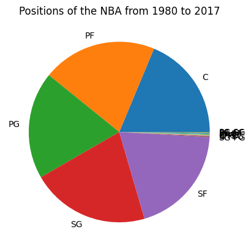

```python
position_count = []
for x in unique_players_seaons["Pos"].unique():
    current =unique_players_seaons[(seasons1980_2017.Pos == x)]
    position_count.append(current.shape[0])

y = position_count
mylabels = unique_players_seaons["Pos"].unique()

plt.title("Positions of the NBA from 1980 to 2017")
plt.pie(y, labels = mylabels)
plt.show()
```

Here we will show the distribution for each decade from the 1980s to the 2010s

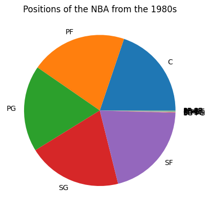

```python
pie1980s = seasons1980_2017[(seasons1980_2017.Year >= 1980) & (seasons1980_2017.Year < 1990)]


position_count = []
for x in pie1980s["Pos"].unique():
    current =pie1980s[(pie1980s.Pos == x)]
    position_count.append(current.shape[0])

y = position_count
mylabels = pie1980s["Pos"].unique()

plt.title("Positions of the NBA from the 1980s")
plt.pie(y, labels = mylabels)
plt.show()
```

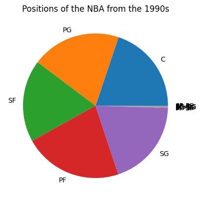

```python
pie1990s = seasons1980_2017[(seasons1980_2017.Year >= 1990) & (seasons1980_2017.Year < 2000)]


position_count = []
for x in pie1990s["Pos"].unique():
    current =pie1990s[(pie1990s.Pos == x)]
    position_count.append(current.shape[0])

y = position_count
mylabels = pie1990s["Pos"].unique()

plt.title("Positions of the NBA from the 1990s")
plt.pie(y, labels = mylabels)
plt.show()
```

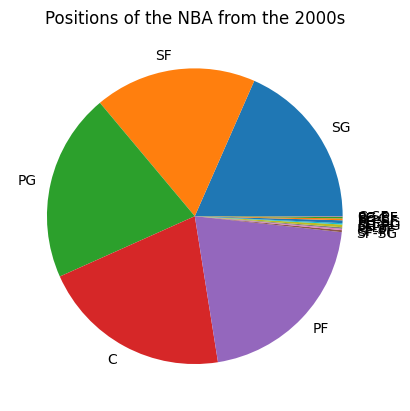

```python
pie2000s = seasons1980_2017[(seasons1980_2017.Year >= 2000) & (seasons1980_2017.Year < 2010)]


position_count = []
for x in pie2000s["Pos"].unique():
    current =pie2000s[(pie2000s.Pos == x)]
    position_count.append(current.shape[0])

y = position_count
mylabels = pie2000s["Pos"].unique()

plt.title("Positions of the NBA from the 2000s")
plt.pie(y, labels = mylabels)
plt.show()
```

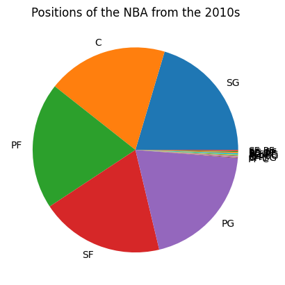

```python
pie2010s = seasons1980_2017[(seasons1980_2017.Year >= 2010)]


position_count = []
for x in pie2010s["Pos"].unique():
    current =pie2010s[(pie2010s.Pos == x)]
    position_count.append(current.shape[0])

y = position_count
mylabels = pie2010s["Pos"].unique()

plt.title("Positions of the NBA from the 2010s")
plt.pie(y, labels = mylabels)
plt.show()
```

Based off of these pie charts, we can see that each position has equally distributed across the league from 1980 to 2017. This also shows that there are enough centers and therefore data on centers to use.

Next, lets look at how height has changed from 1980 to 2017. Most of the time, guards are the shortest while centers are the tallest.

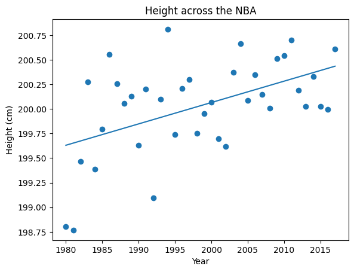

```python
height_count = []
for x in sorted_years:
    current = full_merged_data[(full_merged_data.Year == x)]
    height_count.append(current['height_x'].mean())

model1 = LinearRegression().fit(sorted_years2,height_count)

plt.title("Height across the NBA")
plt.xlabel("Year")
plt.ylabel("Height (cm)")
plt.scatter(x = sorted_years, y = height_count)
plt.plot(sorted_years2,model1.predict(sorted_years2))
```

As we can see from the scatterplot, from 1980 to 2017, the height of players increased in the NBA.

Now lets look at specficially centers. First, we will look at how their scoring has improved over time.

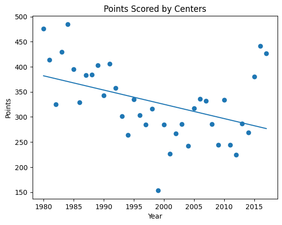

```python
point_count = []
for x in sorted_years:
    current = full_merged_data_C[(full_merged_data_C.Year == x)]
    point_count.append(current['PTS'].mean())

model2 = LinearRegression().fit(sorted_years2,point_count)

plt.title("Points Scored by Centers")
plt.xlabel("Year")
plt.ylabel("Points")
plt.scatter(x = sorted_years, y = point_count)
plt.plot(sorted_years2,model2.predict(sorted_years2))
```

We actually see a decrease in the average number of points scored by centers as time goes on.

Next, lets check how 3 point shooting has changed for centers. First, with 3 pointers attempted.

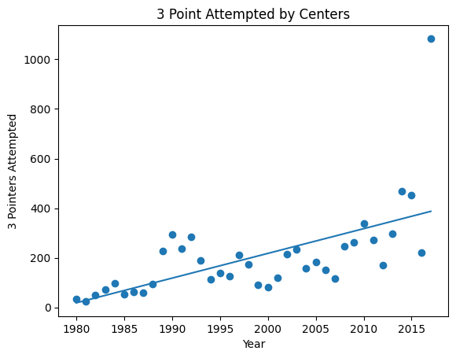

```python
three_pointers_attempted = []
for x in sorted_years:
    current = full_merged_data_C[(full_merged_data_C.Year == x)]
    three_pointers_attempted.append(current['3PA'].sum())

model3 = LinearRegression().fit(sorted_years2,three_pointers_attempted)

plt.title("3 Point Attempted by Centers")
plt.xlabel("Year")
plt.ylabel("3 Pointers Attempted")
plt.scatter(x = sorted_years, y = three_pointers_attempted)
plt.plot(sorted_years2,model3.predict(sorted_years2))
```

```python
threePA_1980 = full_merged_data_C[(full_merged_data_C.Year == 1980)]
print(threePA_1980['3PA'].sum())
threePA_2017 = full_merged_data_C[(full_merged_data_C.Year == 2017)]
print(threePA_2017['3PA'].sum())
threePA_2016 = full_merged_data_C[(full_merged_data_C.Year == 2016)]
print(threePA_2016['3PA'].sum())
```

```
34.0
1084.0
222.0
```

We see a significant increase in the number of 3 pointers attempted by centers as time goes on. They go from nearly zero all the way up to nearly 400 attempts in a season. To be more specific, in 1980, only 34 3 pointers were attempted by centers. in 2017, 1084 three pointers were attempted, 31 times more threes attempted. 2017 may be an outlier, but even so, in 2016, 222 three pointers were attempted, 6.5 times more than 1980.

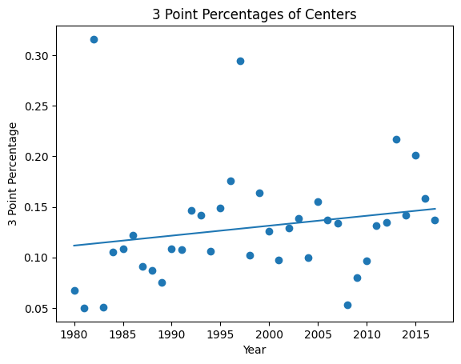

```python
three_pointer_rate = []
for x in sorted_years:
    current = full_merged_data_C[(full_merged_data_C.Year == x)]
    three_pointer_rate.append(current['3P%'].mean())

model4 = LinearRegression().fit(sorted_years2,three_pointer_rate)

plt.title("3 Point Percentages of Centers")
plt.xlabel("Year")
plt.ylabel("3 Point Percentage")
plt.scatter(x = sorted_years, y = three_pointer_rate)
plt.plot(sorted_years2,model4.predict(sorted_years2))
```

```python
print(threePA_1980['3P%'].mean())
print(threePA_2017['3P%'].mean())
```

```
0.06720000000000001
0.13661290322580644
```

Three point rates also increased as time went on. From 1980 to 2017, three point percentages increased from 6.7% to 13.7%, doubling the rate centers make their threes.

Now lets look at assists.

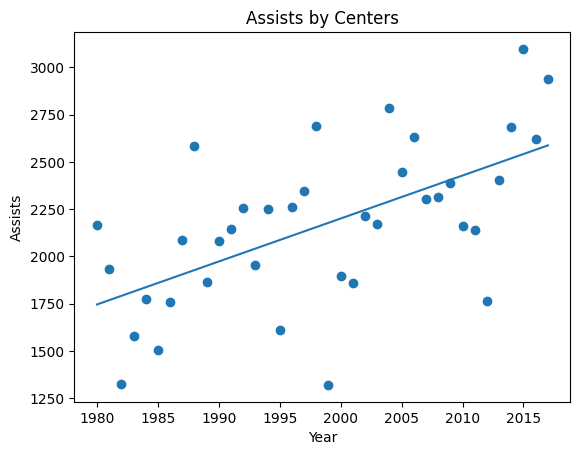

```python
assists_attempted = []
for x in sorted_years:
    current = full_merged_data_C[(full_merged_data_C.Year == x)]
    assists_attempted.append(current['AST'].sum())

model5 = LinearRegression().fit(sorted_years2,assists_attempted)

plt.title("Assists by Centers")
plt.xlabel("Year")
plt.ylabel("Assists")
plt.scatter(x = sorted_years, y = assists_attempted)
plt.plot(sorted_years2,model5.predict(sorted_years2))
```

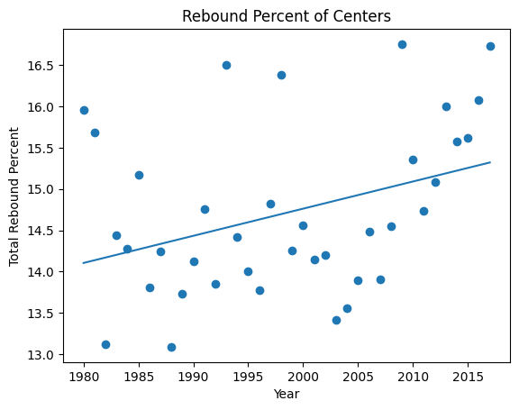

```python
rebound_percent = []
for x in sorted_years:
    current = full_merged_data_C[(full_merged_data_C.Year == x)]
    rebound_percent.append(current['TRB%'].mean())

model6 = LinearRegression().fit(sorted_years2,rebound_percent)

plt.title("Rebound Percent of Centers")
plt.xlabel("Year")
plt.ylabel("Total Rebound Percent")
plt.scatter(x = sorted_years, y = rebound_percent)
plt.plot(sorted_years2,model6.predict(sorted_years2))
```

Traditionally high center stats like total rebound percentage has also grown, increasing by about a percentage.

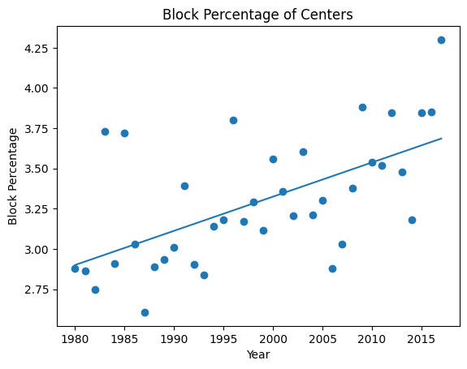

```python
block_percent = []
for x in sorted_years:
    current = full_merged_data_C[(full_merged_data_C.Year == x)]
    block_percent.append(current['BLK%'].mean())

model7 = LinearRegression().fit(sorted_years2,block_percent)

plt.title("Block Percentage of Centers")
plt.xlabel("Year")
plt.ylabel("Block Percentage")
plt.scatter(x = sorted_years, y = block_percent)
plt.plot(sorted_years2,model7.predict(sorted_years2))
```

Block percentage also grew from below 3% to 3.5%.

## **Model: Analysis, Hypothesis Testing, & ML**

During this phase of the Data Lifecycle, we attempt to perform various modeling techniques (such as linear regression or logistic regression) in order to obtain a predictive model of our data. This allows us to predict values for data outside of the scope of our data. For example, we can use a linear regression model to predict if centers will become more creative in the future, as well as how height is an indicator of how creative a given center will be in any given decade.

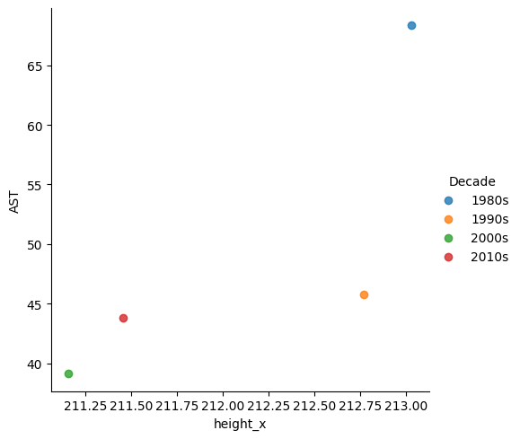

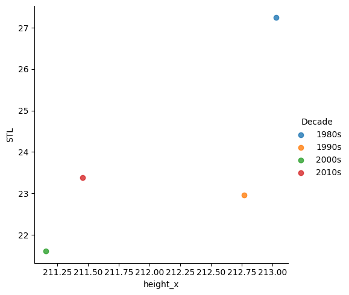

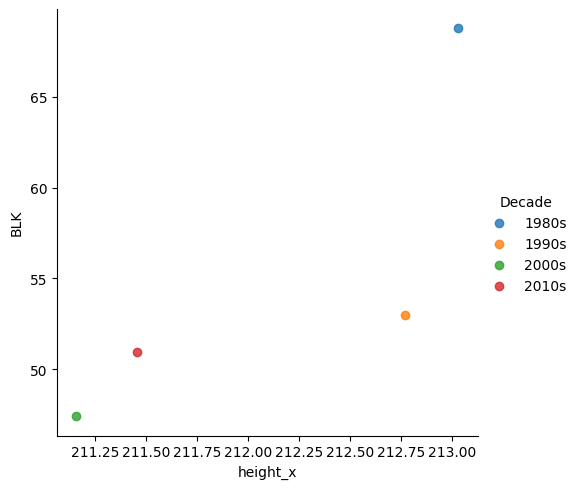

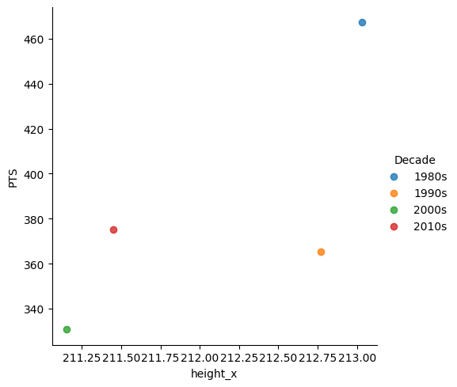

```python
import seaborn as sns
from sklearn.linear_model import LinearRegression
from sklearn.model_selection import train_test_split
from sklearn import metrics
import numpy as np

sns.lmplot(data=avg_all_four_decades, x='height_x', y='AST', hue='Decade')
sns.lmplot(data=avg_all_four_decades, x='height_x', y='STL', hue='Decade')
sns.lmplot(data=avg_all_four_decades, x='height_x', y='BLK', hue='Decade')
sns.lmplot(data=avg_all_four_decades, x='height_x', y='PTS', hue='Decade')
```

We will now attempt to use individual player data during each decade in order to gain further insights into how centers become more/less creative over time or how height affects a given center's creativity in a decade. We start first by using the sklearn library for linear regression and machine learning.

We first choose to concatenate the data across all 4 decades.

The following plot looks at the relationship between height and the number of points a given center would score during each decade.

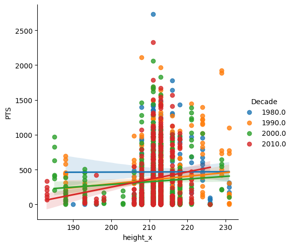

```python
all_seasons = pd.concat([season1980s, season1990s, season2000s, season2010s])

import seaborn as sns
import matplotlib.pyplot as plt

# Create a new column for the decade
all_seasons['Decade'] = all_seasons['Year'].apply(lambda x: (x//10)*10)

# Plot the regression
sns.lmplot(data=all_seasons, x="height_x", y="PTS", hue="Decade")

plt.show()
```

As you can see the lines on this graph are neither clear or give any valuable insight. Instead, we will use the entire data set to see the corelation over time

Next, to fit a Machine Learning model to predict average creative output numbers over time, we'll first need to define what we mean by "creative output numbers". Here, we define it as the sum of assists (AST), steals (STL), and points (PTS) as a general statistic we can use to see how creative a center is

The model.coef_ array will give you the coefficients of the Ordinary Least Squares (OLS) linear regression model, which can be used to predict the creative output given the features.

```python
from sklearn.model_selection import train_test_split
from sklearn.linear_model import LinearRegression

# Create a new column for the creative output
all_seasons['Creative_Output'] = all_seasons['AST'] + all_seasons['STL'] + all_seasons['PTS']

# Define the feature columns and the target column
feature_cols = ['Year', 'height_x', 'AST', 'STL', 'PTS']
target_col = 'Creative_Output'

# Split the data into training and test sets
X_train, X_test, y_train, y_test = train_test_split(all_seasons[feature_cols], all_seasons[target_col], test_size=0.2, random_state=42)

# Fit the model
model = LinearRegression()
model.fit(X_train, y_train)

# Print the coefficients
print("Coefficients: ", model.coef_)
```

```
Coefficients:  [-4.09002856e-15 -6.21724894e-15  1.00000000e+00  1.00000000e+00
  1.00000000e+00]
```

```
Coefficients:  [[-3.71945268]]
Intercept:  [7883.36050571]
Mean squared error: 212260.08
Coefficient of determination: 0.01
```

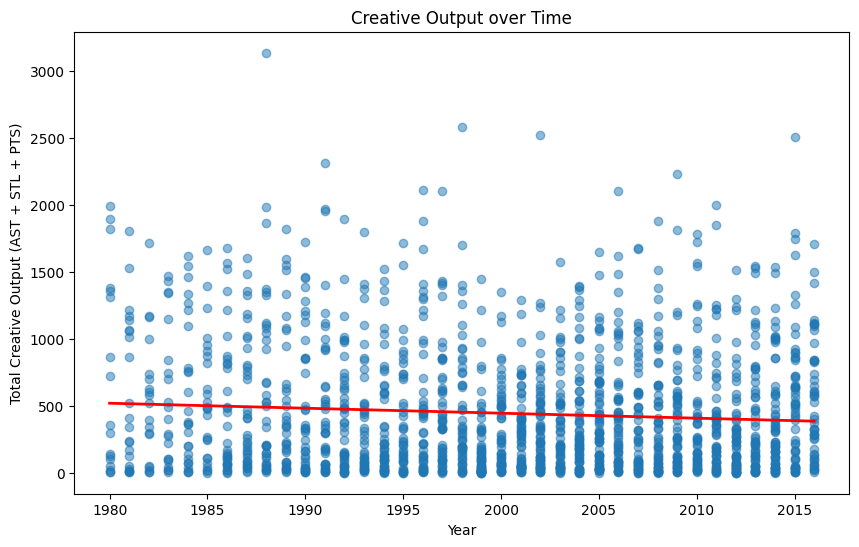

```python
from sklearn.linear_model import LinearRegression
from sklearn.metrics import mean_squared_error, r2_score
import matplotlib.pyplot as plt
import seaborn as sns
import numpy as np

# Combine all the dataframes into a single one
all_seasons = pd.concat([season1980s, season1990s, season2000s, season2010s])

# Create the TotalOutput column
all_seasons['TotalOutput'] = all_seasons['AST'] + all_seasons['STL'] + all_seasons['PTS']

# Define the independent variable and dependent variable
X = all_seasons[['Year']]
y = all_seasons[['TotalOutput']]

# Create a linear regression model and fit it to the data
model = LinearRegression()
model.fit(X, y)

# Print out the coefficients, intercept, mean squared error and the coefficient of determination
predictions = model.predict(X)
print("Coefficients: ", model.coef_)
print("Intercept: ", model.intercept_)
print("Mean squared error: %.2f" % mean_squared_error(y, predictions))
print('Coefficient of determination: %.2f' % r2_score(y, predictions))

ols_mse = mean_squared_error(y, predictions)

# Plot the scatter plot and the regression line
plt.figure(figsize=(10,6))
plt.scatter(X, y, alpha=0.5)
plt.plot(X, predictions, color='red', linewidth=2)
plt.title('Creative Output over Time')
plt.xlabel('Year')
plt.ylabel('Total Creative Output (AST + STL + PTS)')
plt.show()
```

```
Estimated coefficients:  [-1.66480905]
Estimated intercept:  3445.200045166249
Mean squared error: 319836.86
R^2 score: -0.50
```

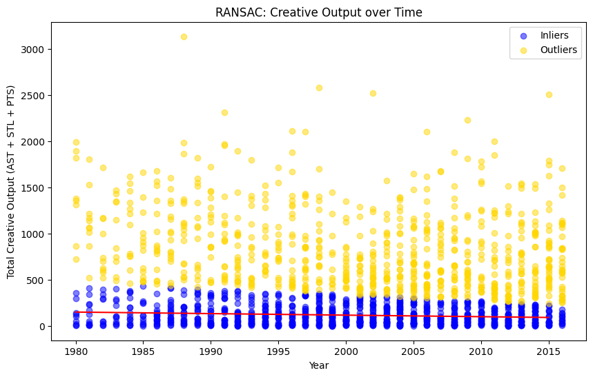

```python
from sklearn.linear_model import RANSACRegressor
from sklearn.metrics import mean_squared_error, r2_score

# Combine all the dataframes into a single one
all_seasons = pd.concat([season1980s, season1990s, season2000s, season2010s])

# Create the TotalOutput column
all_seasons['TotalOutput'] = all_seasons['AST'] + all_seasons['STL'] + all_seasons['PTS']

# Define the independent variable and dependent variable
X = all_seasons[['Year']]
y = all_seasons['TotalOutput']

# Create a RANSAC regression model and fit it to the data
ransac = RANSACRegressor()
ransac.fit(X, y)

# Create a mask for inlier and outlier data points
inlier_mask = ransac.inlier_mask_
outlier_mask = np.logical_not(inlier_mask)

# Print the RANSAC model's estimated coefficients, intercept, mean squared error, and R2 score
predictions = ransac.predict(X)
print("Estimated coefficients: ", ransac.estimator_.coef_)
print("Estimated intercept: ", ransac.estimator_.intercept_)
print("Mean squared error: %.2f" % mean_squared_error(y, predictions))
print('R^2 score: %.2f' % r2_score(y, predictions))

ransac_mse = mean_squared_error(y, predictions)

# Plot the scatter plot with the regression line
line_X = np.arange(X['Year'].min(), X['Year'].max())[:, np.newaxis] # corrected line
line_y_ransac = ransac.predict(line_X)

plt.figure(figsize=(10,6))
plt.scatter(X[inlier_mask], y[inlier_mask], color='blue', alpha=0.5, label='Inliers')
plt.scatter(X[outlier_mask], y[outlier_mask], color='gold', alpha=0.5, label='Outliers')
plt.plot(line_X, line_y_ransac, color='red')
plt.title('RANSAC: Creative Output over Time')
plt.xlabel('Year')
plt.ylabel('Total Creative Output (AST + STL + PTS)')
plt.legend()
plt.show()
```

Next we implement a Support Vector Machines (SVM) and K-Nearest Neighbors (KNN) model in order to see if they may be a better fit than that of the RANSAC model. Here we're using the Measn Squared error of each data set in order to see if they may be a better fit for the data.

```
SVM Mean Squared Error: 223369.38666648432
```

[output not shown]

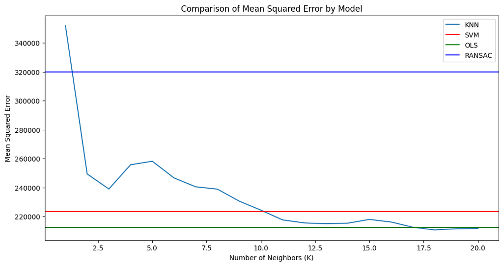

```python
from sklearn.svm import SVR
from sklearn.neighbors import KNeighborsRegressor
from sklearn.model_selection import train_test_split
from sklearn.metrics import mean_squared_error
from tqdm import tqdm

X_train, X_test, y_train, y_test = train_test_split(X, y, test_size=0.2, random_state=42)


svm = SVR()
svm.fit(X_train, y_train)

svm_predictions = svm.predict(X_test)
svm_mse = mean_squared_error(y_test, svm_predictions)

print(f"SVM Mean Squared Error: {svm_mse}")

k_values = list(range(1, 21))
knn_mse_values = []

for k in tqdm(k_values):
    knn = KNeighborsRegressor(n_neighbors=k)
    knn.fit(X_train, y_train)

    knn_predictions = knn.predict(X_test)
    knn_mse = mean_squared_error(y_test, knn_predictions)

    knn_mse_values.append(knn_mse)

print(f"KNN Mean Squared Errors: {knn_mse_values}")

plt.figure(figsize=(12, 6))
plt.plot(k_values, knn_mse_values, label='KNN')
plt.axhline(y=svm_mse, color='r', linestyle='-', label='SVM')
plt.axhline(y=ols_mse, color='g', linestyle='-', label='OLS')
plt.axhline(y=ransac_mse, color='b', linestyle='-', label='RANSAC')
plt.legend()
plt.xlabel('Number of Neighbors (K)')
plt.ylabel('Mean Squared Error')
plt.title('Comparison of Mean Squared Error by Model')
plt.show()
```

As you can see by the graph above, the mean squared error of the OLS model and the KNN model (albeit after a significant number of iterations) are most accurate.

Next, let's compare the Coeifficient of determination of each model:

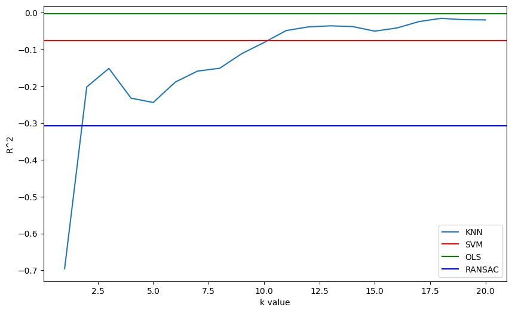

```python
from sklearn.metrics import r2_score
from sklearn.svm import SVR
from sklearn.neighbors import KNeighborsRegressor
from sklearn.linear_model import LinearRegression, RANSACRegressor

# Define your OLS model
model_ols = LinearRegression()
model_ols.fit(X_train, y_train)
ols_predictions = model_ols.predict(X_test)
ols_r2 = r2_score(y_test, ols_predictions)

# Define your RANSAC model
model_ransac = RANSACRegressor()
model_ransac.fit(X_train, y_train)
ransac_predictions = model_ransac.predict(X_test)
ransac_r2 = r2_score(y_test, ransac_predictions)

# Define your SVM model
model_svm = SVR()
model_svm.fit(X_train, y_train)
svm_predictions = model_svm.predict(X_test)
svm_r2 = r2_score(y_test, svm_predictions)

# Define KNN models for different k values
k_values = list(range(1, 21))
knn_r2_values = []

for k in k_values:
    model_knn = KNeighborsRegressor(n_neighbors=k)
    model_knn.fit(X_train, y_train)
    knn_predictions = model_knn.predict(X_test)
    knn_r2 = r2_score(y_test, knn_predictions)
    knn_r2_values.append(knn_r2)

# Plot R^2 values
plt.figure(figsize=(10,6))
plt.plot(k_values, knn_r2_values, label='KNN')
plt.axhline(y=svm_r2, color='r', linestyle='-', label='SVM')
plt.axhline(y=ols_r2, color='g', linestyle='-', label='OLS')
plt.axhline(y=ransac_r2, color='b', linestyle='-', label='RANSAC')
plt.xlabel('k value')
plt.ylabel('R^2')
plt.legend()
plt.show()
```

Data processing (https://www.simplilearn.com/what-is-data-processing-article) EDA (https://www.simplilearn.com/exploratory-data-analysis-article) Hypothesis testing intuition (https://towardsdatascience.com/hypothesis-testing-intuition-701852364717) Hypothesis testing (https://www.ncbi.nlm.nih.gov/pmc/articles/PMC6785820/) ML articles (https://towardsdatascience.com/interesting-ai-ml-articles-you-should-read-this-week-sep-19-92ee6b14c12c)